# Lab 8: Decisions

From a probability to a stake, a price, and a move

## St. Petersburg: the game

- Game: toss a fair coin until the first head, on toss $T$
- Payout: $X = 2^T$ dollars ($2, 4, 8, \dots$)
- Chance of the first head on toss $T$: $2^{-T}$
- Average payout, summing over all tosses:

$$\mathbb{E}(X) = \sum_{T=1}^{\infty} 2^T \cdot 2^{-T} = 1 + 1 + 1 + \dots = \infty$$

- An average-maximizer pays any price. Nobody does.
- Predict: write down your price for one play.

## St. Petersburg: simulation

- Play $n$ rounds, take the sample mean of the payouts, repeat 200 times
- $\log_2 n$: base-2 log of $n$

| $n$ | first run | median of 200 runs | $\log_2 n$ |
| --- | --- | --- | --- |
| 100 | 6.1 | 8.9 | 6.6 |
| 1,000 | 19.5 | 11.9 | 10.0 |
| 10,000 | 19.1 | 15.9 | 13.3 |
| 100,000 | 26.0 | 19.6 | 16.6 |

## St. Petersburg: history

- 1713: Nicolaus Bernoulli poses the game in a letter to Montmort
- 1728: Gabriel Cramer: money is worth less to a person who has more
- 1738: Daniel Bernoulli, paper for the St. Petersburg Academy: marginal value of a dollar $\propto 1/\text{wealth}$, so $u(x) = \log x$
- Value a gamble by $\mathbb{E}\,u(X)$, not by $\mathbb{E}(X)$: expected utility
- 1944: von Neumann and Morgenstern: axioms under which a rational person maximizes $\mathbb{E}\,u(X)$
- Allais (1953) breaks those axioms (later in this lab)

## Utility: power family

- Utility: $u(x)$, the value of a payout $x$ to you
- Power utility with risk aversion $\gamma$:

$$u_\gamma(x) = \frac{x^{1-\gamma} - 1}{1-\gamma}, \qquad u_1(x) = \log x$$

- $\gamma > 0$: concave, risk averse (prefers a sure amount to a fair gamble)
- $\gamma = 0$: straight line, risk neutral (indifferent)
- $\gamma < 0$: convex, risk seeking
- Larger $\gamma$ bends the curve more

## Concave and convex curves

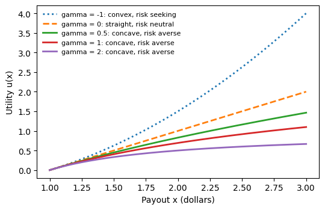

- All curves: $u(1) = 0$, same slope at 1
- Dotted ($\gamma = -1$) bends up, dashed ($\gamma = 0$) is straight, solid bend down more as $\gamma$ grows

## The 50/150 gamble

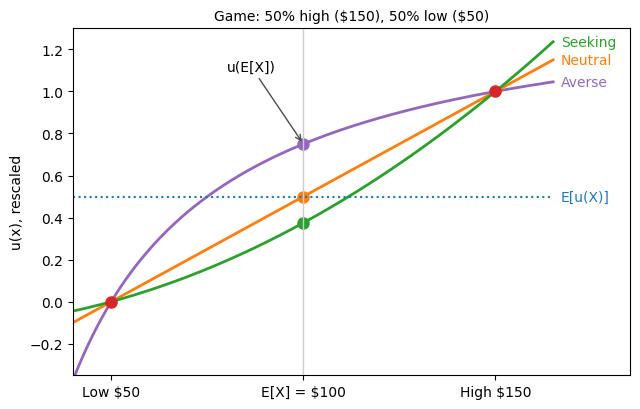

- Gamble: $X = 50$ or $150$, chance $1/2$ each, so $\mathbb{E}(X) = 100$
- Curves rescaled: $u(50) = 0$, $u(150) = 1$
- $\mathbb{E}\,u(X) = 0.5$ for everyone
- Sure $100 has utility $u(\mathbb{E}X)$:
  - averse: 0.750, above 0.5
  - neutral: 0.500, equal
  - seeking: 0.375, below 0.5

## Certainty equivalent

- Certainty equivalent (CE): the sure payout with the same utility as the game, $u(\text{CE}) = \mathbb{E}\,u(X)$
- Concave $u$: $u(\mathbb{E}X) > \mathbb{E}\,u(X)$, so CE $< \mathbb{E}X$
- CE of the St. Petersburg game, summing the first $K$ tosses:

| $\gamma$ | CE, $K = 50$ | CE, $K = 200$ |
| --- | --- | --- |
| 0 (neutral) | 50 | 200 |
| 0.5 | 5.83 | 5.83 |
| 2 | 3.00 | 3.00 |
| 5 | 2.36 | 2.36 |

- Only $\gamma > 0$ gives a finite CE; more risk averse means smaller CE
- Exercise 8.1: CE of the game under log utility

## Your own $\gamma$

- Treat your price as your CE
- Find $\gamma$ with $\text{CE}(\gamma) = \text{price}$ ($K = 1000$)
- Higher price, smaller $\gamma$
- Example: price $5 gives $\gamma = 0.65$

| price ($) | $\gamma$ |
| --- | --- |
| 3 | 2.00 |
| 5 | 0.65 |
| 10 | 0.22 |
| 20 | 0.09 |

Median $\gamma$ (made-up class): 0.65

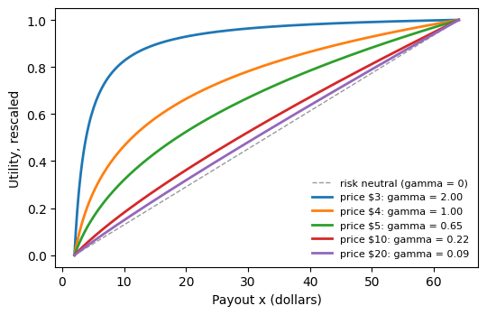

Curves rescaled: 0 at $2, 1 at $64. Dashed: risk neutral.

## Kelly: the bet

- Payout $O$: what a winning $1 ticket pays back, stake included. $O = 3.5$
- Chance of winning $c$. $c = 0.32$ (made up)
- Break-even chance: $1/O = 1/3.5 = 0.286$
- Edge: expected profit on a $1 bet

$$\text{edge} = c\,(O-1) - (1-c) = cO - 1 = 0.32 \times 3.5 - 1 = 0.120$$

- Kelly share: the share $f$ of the bankroll $W$ bet each time that maximizes the average log growth

$$f = \frac{\text{edge}}{O-1} = \frac{cO - 1}{O - 1} = \frac{0.120}{2.5} = 0.048$$

## Kelly: derivation from log utility

- $b = O - 1$: profit on a winning $1. Bet share $f$ of bankroll $W$
- Win (chance $c$): $W(1 + bf)$. Loss (chance $1-c$): $W(1-f)$

$$\mathbb{E}\log(\text{bankroll}) = \log W + c\log(1+bf) + (1-c)\log(1-f)$$

- Set the derivative in $f$ to zero:

$$\frac{cb}{1+bf} - \frac{1-c}{1-f} = 0 \;\Rightarrow\; cb(1-f) = (1-c)(1+bf) \;\Rightarrow\; bf = cb - (1-c)$$

$$f = \frac{c(O-1) - (1-c)}{O-1} = \frac{cO-1}{O-1}$$

- If the edge is 0 or below, $f = 0$: no bet
- Full Kelly on $10,000: $0.048 \times 10{,}000 = \$480$

## Half Kelly and the growth curve

- $c_{\text{true}}$: the real chance of winning, may differ from $c$
- Growth per bet:

$$g(f) = c_{\text{true}}\log\bigl(1+(O-1)f\bigr) + (1-c_{\text{true}})\log(1-f)$$

- Typical bankroll after $n$ bets: $W e^{ng}$
- Half Kelly: $0.5f = 0.024$, stake $240

| $c_{\text{true}}$ | share | $g$ | after 1,000 bets |
| --- | --- | --- | --- |
| 0.32 | full | +0.00282 | $167,068 |
| 0.32 | half | +0.00213 | $83,898 |
| 0.30 | full | $-0.00043$ | $6,475 |
| 0.30 | half | +0.00048 | $16,093 |

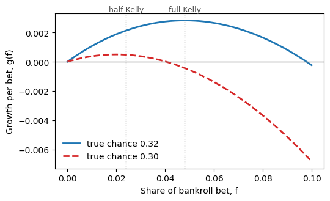

Peak: 0.048 at $c_{\text{true}} = 0.32$, 0.020 at 0.30. Dotted lines: half and full Kelly.

## Kelly: simulating many bettors

- 1,000 bettors, 1,000 bets each, start $10,000, same outcomes for all
- $f^\star = 0.048$: full Kelly

| share of Kelly | median final | share below start |
| --- | --- | --- |
| 0.5 | $83,898 | 3.7% |
| 1 | $167,068 | 10.8% |
| 2 | $12,288 | 48.5% |

- Full Kelly mean: $1,996,386, far above the median: a few lucky bettors
- Judge Kelly by $g$, not by the mean
- Exercise 8.2: half Kelly stake for $O = 5$, $c = 0.28$

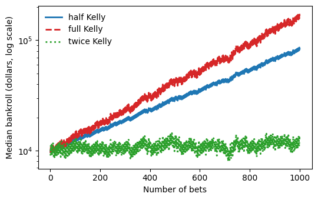

Median bankroll, log scale. Twice Kelly: $g = 0.00021$, goes nowhere.

## Benter, race 1159: board and cut

Happy Valley, 25 Nov 1998, ten horses.

| horse | $O$ | $1/O$ |
| --- | --- | --- |
| 1 | 8.1 | 0.123 |
| 2 | 9.5 | 0.105 |
| 3 | 3.5 | 0.286 |
| 4 | 19.0 | 0.053 |
| 5 | 9.7 | 0.103 |
| 6 | 13.0 | 0.077 |
| 7 | 6.0 | 0.167 |
| 8 | 6.2 | 0.161 |
| 9 | 14.0 | 0.071 |
| 10 | 13.0 | 0.077 |

- Payout $O$: what a winning $1 ticket pays back. Not the odds $p/(1-p)$
- Break-even chance: $1/O$
- Track cut: share of every dollar the track keeps. Payouts shrink by $1 - \text{cut}$, so $\sum 1/O = 1/(1-\text{cut})$:

$$\text{cut} = 1 - \frac{1}{\sum 1/O} = 1 - \frac{1}{1.2234} = 0.183$$

- The track keeps about 18.3 cents per dollar (HKJC take: 17.5%)

## Benter: the crowd’s chance $q$

- $q$: the crowd’s chance that the horse wins, read from the payouts
- Dividing by $\sum 1/O$ removes the cut:

$$q = \frac{1/O}{\sum_{\text{horses}} 1/O}, \qquad q_3 = \frac{0.286}{1.2234} = 0.234$$

- The ten values of $q$ add to 1
- $q \times O = 1/\sum(1/O) = 1 - \text{cut} = 0.817$ for every horse
- If the crowd is right, each $1 bet returns 82 cents on average
- To profit on horse 3, Benter’s chance must beat $1/O = q/(1-\text{cut}) = 0.286$

## Benter: correct the crowd, test the edge

- Benter’s chance $c$: raise $q$ to a power $\alpha$ and rescale (softmax of $\alpha \log q$)

$$c = \frac{q^{\alpha}}{\sum q^{\alpha}}, \qquad \alpha = 1.06 \text{ (max likelihood, 5,873 races)}$$

- Edge: $cO - 1$. Bet only if the edge is above 0, that is $c > 1/O$

| horse | $O$ | $q$ | $c$ | edge $cO-1$ |
| --- | --- | --- | --- | --- |
| 3 | 3.5 | 0.234 | 0.244 | $-0.147$ |
| 7 | 6.0 | 0.136 | 0.138 | $-0.174$ |
| 4 | 19.0 | 0.043 | 0.041 | $-0.229$ |

- All ten edges are negative; best is horse 3: a $1 bet loses about 15 cents
- Horse 3 has $c = 0.244$, needs above $0.286$
- Benter does not bet on this race. The usual answer: a small correction cannot beat an 18% cut

## Benter: the what-if

- Suppose the full model gives horse 3 the chance $c = 0.32$ (made up)
- Edge: $0.32 \times 3.5 - 1 = 0.120$, above 0: bet
- Full Kelly: $f = 0.048$, stake $480 on $10,000
- Benter stakes half Kelly: $240, since $c$ is only an estimate
- Horse 8 won. The bankroll is now $10{,}000 - 240 = \$9{,}760$
- A good bet can lose. The edge shows up over many races.
- Left out: pari-mutuel payouts move with his own bets, joint stakes, odds change until the start

## Benter on 40 years of Hong Kong races

- Data: 1979 to 2018, 265,512 horses in 22,979 races
- Cut of each race: $1 - 1/\sum(1/O)$, median 0.185
- Drop races with cut outside 0.10 to 0.25 (wrong payouts): 1,853
- Kept: 21,126 races, 247,792 horses
- Calibration: 10 bins by $q$; compare average $q$ with win rate

| bin | avg $q$ | win rate |
| --- | --- | --- |
| lowest | 0.0086 | 0.0054 |
| 5th | 0.0514 | 0.0521 |
| 9th | 0.1602 | 0.1642 |
| top | 0.2815 | 0.2843 |

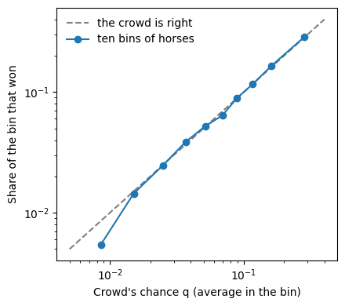

Dashed line: crowd exactly right.

## Hong Kong: fit $\alpha$ on seasons 1999 to 2010

- Conditional logit in each race: score $\alpha\log q$, chance $c$ = softmax
- Train: 1999 to 2010 (5,997 races). Test: 2013 to 2017 (3,860 races). 2011 and 2012 unused.
- Fitted $\alpha = 1.047$ (compare 1.06)
- Log-likelihood (sum of log winner chance, larger is better):

| model | log-likelihood | pseudo $R^2$ |
| --- | --- | --- |
| equal chances | $-15{,}062.7$ | 0 |
| crowd ($\alpha = 1$) | $-12{,}417.8$ | 0.1756 |
| fitted | $-12{,}413.4$ | 0.1759 |

- Pseudo $R^2 = 1 - \text{LL}/\text{LL}_{\text{equal}}$
- Likelihood-ratio statistic: $2 \times 4.35 = 8.70$, above 3.84: $\alpha$ is really above 1
- The crowd explains almost all of it

## Hong Kong: the draw at Happy Valley

- Draw: starting gate. Rescaled: $\text{draw\_rel} = (\text{draw} - 1)/(\text{field} - 1)$, 0 at the rail, 1 at the widest gate
- Models, with weight $\beta$:

$$c \propto e^{\beta\,\text{draw\_rel}}, \qquad c \propto e^{\alpha\log q + \beta\,\text{draw\_rel}}$$

- $e^{\beta}$: factor on the horse’s odds of winning ($p/(1-p)$) from rail to widest gate

| 1,957 training races | $e^{\beta}$ | LR statistic |
| --- | --- | --- |
| draw alone | 0.41 | 159.7 |
| crowd and draw | 0.90 | 1.9 |

- Draw alone matters a lot (LR far above 3.84)
- With $q$ in the model, almost nothing is left: the payout already prices the draw
- Sha Tin (your turn): draw alone 0.80, with crowd 1.12

## Hong Kong: test seasons, the model places no bets

- Test seasons 2013 to 2017, nothing fitted on them
- Bet $1 on every horse with edge $cO - 1 > 0$

| model | horses | positive edge | largest edge |
| --- | --- | --- | --- |
| $\alpha$ only, all races | 47,876 | 0 | $-0.063$ |
| $\alpha$ and draw, Happy Valley | 16,383 | 0 | $-0.058$ |

## Allais: the certainty effect

Prizes in millions of dollars. Utility $u(\$0) = 0$, $u(\$25\text{m}) = 1$, $u(\$5\text{m})$ free.

|  | $25m | $5m | $0 |
| --- | --- | --- | --- |
| $G_1$ | 0 | 1 | 0 |
| $G_2$ | 0.10 | 0.89 | 0.01 |
| $G_3$ | 0 | 0.11 | 0.89 |
| $G_4$ | 0.10 | 0 | 0.90 |

- Q1: $G_1$ or $G_2$? Q2: $G_3$ or $G_4$?
- Independence axiom: mixing both gambles with the same third gamble cannot change the choice
- Under expected utility, both differences are the same number:

$$\text{EU}(G_1) - \text{EU}(G_2) = \text{EU}(G_3) - \text{EU}(G_4) = 0.11\,u(\$5\text{m}) - 0.10$$

- Positive when $u(\$5\text{m}) > 0.909$

## Allais: what people do

- Expected utility allows only $(G_1, G_3)$ or $(G_2, G_4)$
- Many choose $(G_1, G_4)$: sure $5m in Q1, 10% shot at $25m in Q2
- Made-up class tally: 13 of 30 consistent, 17 of 30 broke it
- Certainty effect: losing certainty ($G_1$ to $G_2$) hurts more than losing 11 points elsewhere ($G_3$ to $G_4$)
- Check: $u(\$5\text{m}) = 0.95$ gives $0.11 \times 0.95 - 0.10 = 0.0045 > 0$, so $G_1$ and $G_3$

## Ellsberg: ambiguity

- Jar A: 50 red, 50 black. Jar B: 100 balls, unknown mix
- Name a color, draw a ball, win $100 on a match
- Most pick jar A for red and for black
- Picking A for red implies fewer than 50 red in B. Picking A for black implies fewer than 50 black in B. Both cannot hold.
- Ambiguity aversion: dislike of not knowing the chances
- Knight (1921): risk means known chances, uncertainty means unknown chances
- Ellsberg, 1961

## Capacities and the Choquet integral

- Keep a set of possible probabilities, not one. Jar B: 40 to 60 red, so $P(\text{red}) \in [0.4, 0.6]$
- Maxmin expected utility (Gilboa and Schmeidler, 1989): judge each bet by its worst probability in the set
- Capacity: for each event, its worst-case chance over the set (Choquet, 1953)

| event | capacity |
| --- | --- |
| red | 0.4 |
| black | 0.4 |
| red or black | 1 |

- Red plus black is 0.8, not 1: each color gets its own worst case
- Choquet integral: the average using the capacity. A pessimist’s average, equal to the worst average over the set.
- Losses: the supremum over the set of the expected loss
- Jar A: 0.5 beats 0.4 both times, as people choose
- One known probability: Choquet integral is the ordinary average

## Winner’s curse

- Claim a horse for $20,000. Improves with chance 1/2, then worth $50,000, else 0. Average $25,000. Owners who know sell the bad ones.
- Auction: true value $V \sim N(100, 10^2)$, each of $n$ bidders gets $V$ plus $N(0, 10^2)$ noise and bids $k$ times the estimate. Winner is the highest estimate. Profit is $V - \text{winning bid}$.

$$\text{profit} = 0 \text{ when } k = \frac{\mathbb{E}V}{\mathbb{E}[\text{highest estimate}]}$$

| bidders $n$ | mean winning estimate | winner profit at $k=1$ | break-even $k$ |
| --- | --- | --- | --- |
| 1 | 100.04 | $-0.03$ | 0.9997 |
| 2 | 105.66 | $-5.65$ | 0.9465 |
| 5 | 111.64 | $-11.63$ | Exercise 8.3 |
| 20 | 118.67 | $-18.66$ | 0.8427 |

- More bidders: higher top estimate, more shading needed

## Lemons

- Akerlof (1970). Lemon worth $5K to the buyer, good car $25K. Lemon sellers accept $\ge 5$K, good sellers $\ge 20$K.
- $\pi$: share of lemons. A buyer pays the average value:

$$\text{price} = 25(1-\pi) + 5\pi \quad (\text{thousand dollars})$$

- Good cars trade only if price $\ge 20$, that is $\pi \le 0.25$

| lemon share $\pi$ | buyer pays | good cars sell | share that trade |
| --- | --- | --- | --- |
| 0.10 | $23K | yes | 1.00 |
| 0.25 | $20K | yes | 1.00 |
| 0.50 | $15K | no | 0.50 |

- At $\pi = 0.5$ only lemons trade, at $5K
- Unraveling: buyer pays 1.5 times the average value on offer. Cars on offer: 100%, 75%, 56%, 42%, … 10% after 8 rounds
- Cure: warranties, inspections, reputation

## The value of a test

- Prior 0.02, sensitivity 0.95, specificity 0.99
- Utility: treat 90 (healthy or sick), no treat 100 (healthy) or 0 (sick)
- No test: treat gives 90; no treat gives $100(1-\text{prior}) = 98$
- $P(+) = 0.95 \times 0.02 + 0.01 \times 0.98 = 0.0288$
- $P(\text{sick} \mid +) = 0.019/0.0288 = 0.660$: treat, 90
- $P(\text{sick} \mid -) = 0.001$: no treat, 99.90
- With test: $0.0288 \times 90 + 0.9712 \times 99.90 = 99.61$

$$\text{value} = 99.61 - 98 = 1.61$$

- Buy when value $>$ cost (cost 1 point)
- Peak 8.46 points at prior 0.10; zero near 0 and near 1

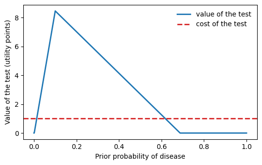

Dashed: test cost.

## Nash: the marble game

- $A$ and $B$ show red or blue at once. Both red: $A$ wins $3. Both blue: $A$ wins $1. Colors differ: $B$ wins $2.
- $p_A$, $p_B$: chance that $A$, $B$ shows red
- $B$ makes $A$ indifferent: red earns $A$ $3p_B$, blue earns $1 - p_B$

$$3p_B = 1 - p_B \;\Rightarrow\; p_B = \tfrac14$$

- $A$ makes $B$ indifferent: red earns $B$ $2(1-p_A)$, blue earns $2p_A$

$$2(1-p_A) = 2p_A \;\Rightarrow\; p_A = \tfrac12$$

- Equilibrium payoffs: $A$ gets $3p_B = \$0.75$, $B$ gets $2(1-p_A) = \$1.00$
- At equilibrium, red and blue earn the same against the other’s mix: no solo change helps
- Playing red more than equilibrium can be exploited. Exercise 8.5: change both red to $4.

## Graded exercises

- 8.1: certainty equivalent of the St. Petersburg game under log utility, first 200 tosses
- 8.2: half Kelly stake for $O = 5$, $c = 0.28$, bankroll $8,000
- 8.3: shading factor $k$ at which the winner’s average profit is 0, 5 bidders
- 8.4: range of priors where the test is worth its cost of 1
- 8.5: mixed equilibrium of the marble game with prize $4 for both red
- 8.6 (at home): fair price of the St. Petersburg game with a $1 million bankroll cap
- Exit problem on paper: log-utility lottery comparison, then edge, Kelly, half Kelly stake

## Takeaways

- Average payout is a poor guide: use utility, $u(\text{CE}) = \mathbb{E}\,u(X)$
- Kelly: $f = (cO-1)/(O-1)$ maximizes growth $g(f)$; bet half when $c$ is an estimate
- Benter: $q = (1/O)/\sum(1/O)$, $c \propto q^{\alpha}$, bet only if $cO - 1 > 0$
- Hong Kong data: the crowd is nearly calibrated, a small correction cannot beat an 18% cut
- Allais and Ellsberg: people break independence and dislike ambiguity; use a set of probabilities and its worst case
- Winner’s curse and lemons: the winning or the willing side has bad news; shade bids, add information
- Test value: value $=$ EU with test $-$ EU without; Nash: make the other player indifferent